# Data Science: Ribs

Cooking ribs on July 10, 2018 using the Weber Smoky Mountain smoker, mostly following the method outlined at the [Virtual Weber Bullet](http://virtualweberbullet.com/rib2.html).

Here’s what they looked like to start, using two racks of St. Louis ribs from our [awesome neighborhood butcher](http://avedanos.com/). Had to cut down the two racks to fit in the smoker:

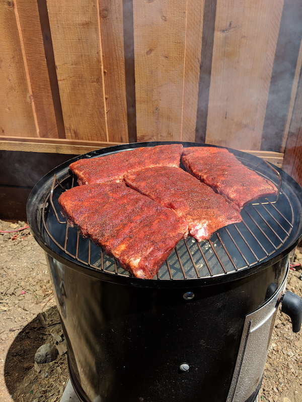

Ribs going into the smoker

This code plots the meat and air temperature, both measured using the Maverick BBQ thermometer. The vents all started at about 10% open, and the dashed vertical lines indicate changes in venting (closing in red, opening in green). The black dotted line indicates points when we removed the cover to check the meat and baste it with a bit of apple juice (and sometimes add more water to the pan).

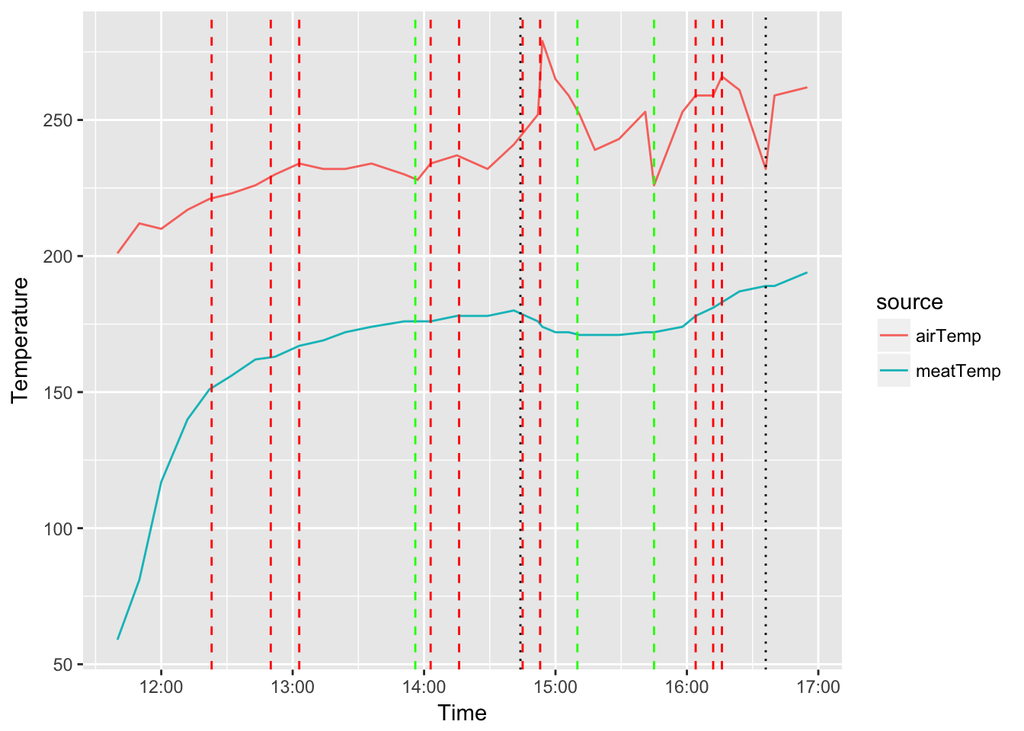

```r
library(ggplot2)
library(dplyr)
library(tidyr)

time=c('11:40','11:50','12:00','12:12','12:22','12:32','12:43','12:52','13:03','13:14','13:24','13:36','13:51','13:57','14:03','14:15','14:29','14:41',"14:52","14:54",'15:00','15:06','15:11','15:18','15:29','15:41','15:45','15:58','16:04','16:12','16:16','16:24','16:36','16:40','16:55')
meatTemp=c(59,81,117,140,151,156,162,163,167,169,172,174,176,176,176,178,178,180,176,174,172,172,171,171,171,172,172,174,178,181,183,187,189,189,194)
airTemp=c(201,212,210,217,221,223,226,230,234,232,232,234,230,228,234,237,232,241,252,279,265,259,252,239,243,253,226,253,259,259,266,261,232,259,262)

hm=as.POSIXct(strptime(time, '%H:%M',tz='GMT'))
df=data.frame(meatTemp,airTemp,hm) %>%
  gather(source,temp,-hm)
p=ggplot(df,aes(hm,temp,color=source)) +
  geom_line() +
  ylab('Temperature') +
  xlab('Time')

# add horizontal lines for vent adjustments
reductions=c('12:23','12:50','13:03','14:03','14:16','14:45','14:53','16:04','16:12','16:16')
for (t in reductions){
  p = p + geom_vline(xintercept = as.POSIXct(strptime(t, '%H:%M',tz='GMT')) ,linetype='dashed',size=0.5,color='red')
}
increases=c('13:56','15:10','15:45')
for (t in increases){
  p = p + geom_vline(xintercept = as.POSIXct(strptime(t, '%H:%M',tz='GMT')) ,linetype='dashed',size=0.5,color='green')
}
checking=c('14:44','16:36')
for (t in checking){
  p = p + geom_vline(xintercept = as.POSIXct(strptime(t, '%H:%M',tz='GMT')) ,linetype='dotted',size=0.5,color='black')
}

print(p)
```

The cooker temperature was remarkably stable for the first 2 1/2 hours today, with little need to futz with the vents. However, after checking it for doneness at 3 hours, the temp went a bit out of control and I had to shut the vents completely to get it back into range.

I’ve never used internal temperature with ribs before – based on [Are my ribs ready yet?](https://amazingribs.com/tested-recipes/pork-ribs-recipes/are-my-ribs-ready-yet) I’m shooting for 195-200, but will test with the “tear test” once we hit 4 hours even if temp is not there. Also interested to see if we get a [stall](https://amazingribs.com/more-technique-and-science/more-cooking-science/understanding-and-beating-barbecue-stall-bane-all) with ribs like one does with brisket.

We took the ribs off after a bit more than 5 hours, right when they hit 195 degrees.

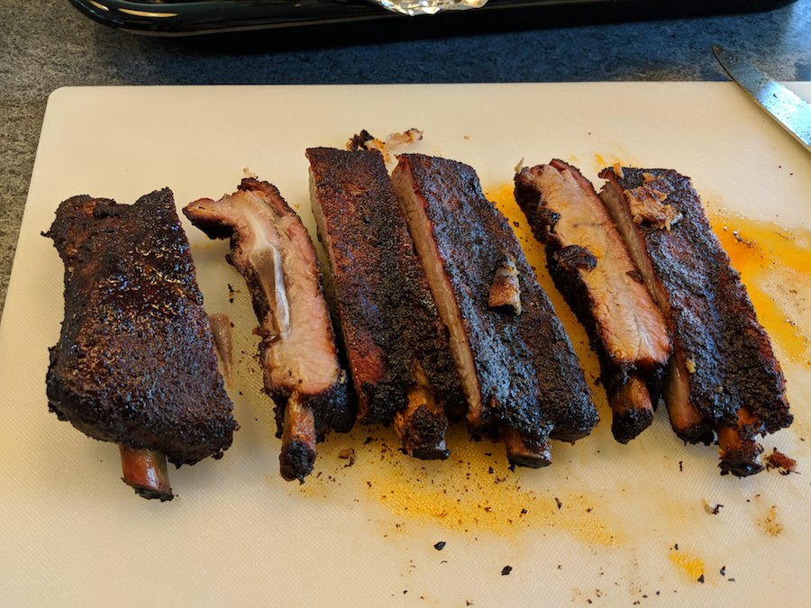

The final product

### The verdict

Overall the ribs were very tasty and well cooked - the thinner ends were a bit overcooked and disintegrating, but the thicker parts were perfectly done. My main change for next time would be to use a lot more black pepper in the rub - I was a bit skimpy this time and it showed.